# Dimer of spheres

11 October, 2021

## Objective

This example illustrates on a very simple case the calculation of far-field spectra for absorption, scattering, and extinction. The structure consists of two silver spheres in water, and all parameters are kept to their default values.

This simulation uses the following `input` file

```
Wavelength 300 900 300

Medium 1.7689 # epsilon of water

Scatterers 2
Ag 0.0 -50.0 0.0 30.0
Ag 0.0  50.0 0.0 30.0
```

The command to run the example is simply

```
../../build/terms input > log
```

The full log contains basic details of the calculations, and finishes with the timing.

**Show log file (click to open)**

```
readInputFile> Parsing file input

readInputFile> Detected keyword Wavelength
               Wavelength LB (nm):   300.000000
               Wavelength UB (nm):   900.000000
               nsteps, step:       300    2.0000
readInputFile> Detected keyword Medium
               Constant host epsilon=  1.7689E+0

readInputFile> Detected keyword Scatterers
 with nscat=    2

readInputFile> Descriptor(s) and circumscribing sphere(s):

 scatID String                  x          y          z         R_0
    1   Ag                  0.0000E+0 -5.0000E+1  0.0000E+0  3.0000E+1
    2   Ag                  0.0000E+0  5.0000E+1  0.0000E+0  3.0000E+1

readInputFile> Individual geometry characteristic(s):

 scatID Details
    1   Mie with ncoats= 0
    2   Mie with ncoats= 0

readInputFile> Dielectric functions for (coated) Mie scatterer(s):

 scatID volID Label
    1     0     Ag
    2     0     Ag

readInputFile> Finished parsing  3 keywords


spectrumFF> ===== Wavelength:   300.00 (nm) ======================

           1
           2
           3
           4
solve> Prestaging...
solve> Staging and solving/inverting...
solve> Done!

calcOAprops> <csExt>=  2.48657647E+03 nConv=  8
             <csSca>=  1.98297386E+03 nConv=  8
             <csAbs>=  5.03602604E+02

             <cdExt>= -3.36598739E-13
             <cdSca>= -2.85937020E-13
             <cdAbs>= -5.06617189E-14

           1
calcCs> csExt=  2.75907731E+03 nConv=  0
         csSca=  2.16250260E+03 nConv=  8
         csAbs=  5.96574715E+02

           2
calcCs> csExt=  2.89262954E+03 nConv=  0
         csSca=  2.40883355E+03 nConv=  8
         csAbs=  4.83795996E+02

           3
...
termsProgram> Program run time (CPU & real in s):  1.765E+01  9.233E+00
```

The output consists of a number of files, storing the far-field cross-sections for each order from 1 to $n_{1}$.

```
 [1] "cdAbsOA.dat"                "cdExtOA.dat"
 [3] "cdScaOA.dat"                "csAbs1X_scat001coat0.dat"
 [5] "csAbs1X_scat002coat0.dat"   "csAbs1X.dat"
 [7] "csAbs2Y_scat001coat0.dat"   "csAbs2Y_scat002coat0.dat"
 [9] "csAbs2Y.dat"                "csAbs3R_scat001coat0.dat"
[11] "csAbs3R_scat002coat0.dat"   "csAbs3R.dat"
[13] "csAbs4L_scat001coat0.dat"   "csAbs4L_scat002coat0.dat"
[15] "csAbs4L.dat"                "csAbsOA_split_particle.dat"
[17] "csAbsOA.dat"                "csExt1X.dat"
[19] "csExt2Y.dat"                "csExt3R.dat"
[21] "csExt4L.dat"                "csExtOA.dat"
[23] "csSca1X.dat"                "csSca2Y.dat"
[25] "csSca3R.dat"                "csSca4L.dat"
[27] "csScaOA.dat"
```

the first lines of `csAbsOA.dat` are shown below.

**Show output file (click to open)**

```bash
head csAbsOA.dat
```

```
# Wavelength | Total | n= 1 | ...
  300.000000  5.03602603744949647E+02  3.31261376352353409E+02  1.40150383065914468E+02  2.91720951695711079E+01  2.83312504366855622E+00  1.78212234756965127E-01  7.19892922602280785E-03  2.08456553501993084E-04  4.49290655666220471E-06
  302.000000  5.22685636977922968E+02  3.44748521382053923E+02  1.44811457687040615E+02  3.00383695626867535E+01  2.89885252892007816E+00  1.80976730313776313E-01  7.24681749146867046E-03  2.07835321730690474E-04  4.43409486109945302E-06
  304.000000  5.42816680345133591E+02  3.58914522985891836E+02  1.49764760134740357E+02  3.09739549735456023E+01  2.97172252017957961E+00  1.84193586799422271E-01  7.31393825564216268E-03  2.07815696647910232E-04  4.39002370703773788E-06
  306.000000  5.64076433303224803E+02  3.73803537698749778E+02  1.55038231146349176E+02  3.19865823161028118E+01  3.05255496433436635E+00  1.87912006456199210E-01  7.40205770507339472E-03  2.08436956205719200E-04  4.67656990390098389E-06
  308.000000  5.86554296776616866E+02  3.89463393621880641E+02  1.60663507702742208E+02  3.30851676943918918E+01  3.14230954193719603E+00  1.92190480838204975E-01  7.51333164740923976E-03  2.09749677141107821E-04  4.65350292400373501E-06
  310.000000  6.10349679932136041E+02  4.05945987547256664E+02  1.66676566659501873E+02  3.42800444478820197E+01  3.24211553652504536E+00  1.97098879583437275E-01  7.65039502558012216E-03  2.11818255260690091E-04  4.64810573274870900E-06
  312.000000  6.35573567341364196E+02  4.23307740879243283E+02  1.73118508510429706E+02  3.55832512813657331E+01  3.35330967064847130E+00  2.02721135065831337E-01  7.81647859383865877E-03  2.14724241000503746E-04  4.66177612159979428E-06
  314.000000  6.62350420150793525E+02  4.41610127068234306E+02  1.80036518196980865E+02  3.70088928388524465E+01  3.47748448824769207E+00  2.09158728689936818E-01  8.01556261806256505E-03  2.18570796957993999E-04  4.69637278669797443E-06
  316.000000  6.90820500283441561E+02  4.60920287212480616E+02  1.87485051357418627E+02  3.85735947571601088E+01  3.61655086187722485E+00  2.16535269678322151E-01  8.25258176121758391E-03  2.23488723765209317E-04  4.75434229311276841E-06
```

## Orientation-averaged results

The following files contain orientation-averaged cross-sections,

```
[1] "cdAbsOA.dat" "csAbsOA.dat" "cdExtOA.dat" "csExtOA.dat" "cdScaOA.dat"
[6] "csScaOA.dat"
```

```
Rows: 8,127
Columns: 5
$ wavelength <dbl> 300, 302, 304, 306, 308, 310, 312, 314, 316, 318, 320, 322,…
$ crosstype  <chr> "Abs", "Abs", "Abs", "Abs", "Abs", "Abs", "Abs", "Abs", "Ab…
$ variable   <fct> total, total, total, total, total, total, total, total, tot…
$ dichroism  <dbl> -5.066172e-14, -4.587311e-13, -1.339942e-13, -6.323386e-13,…
$ average    <dbl> 503.6026, 522.6856, 542.8167, 564.0764, 586.5543, 610.3497,…
```

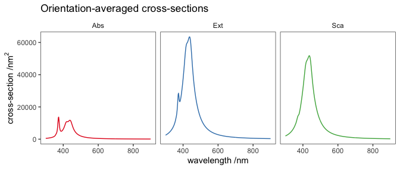

Note that for this achiral dimer, there is no circular dichroism.

## Fixed-orientation results

The following files contain fixed-orientation cross-sections for X and Y linear polarisations,

```
[1] "csAbs1X.dat" "csAbs2Y.dat" "csExt1X.dat" "csExt2Y.dat" "csSca1X.dat"
[6] "csSca2Y.dat"
```

```
Rows: 8,127
Columns: 7
$ wavelength    <dbl> 300, 302, 304, 306, 308, 310, 312, 314, 316, 318, 320, 3…
$ crosstype     <chr> "Abs", "Abs", "Abs", "Abs", "Abs", "Abs", "Abs", "Abs", …
$ variable      <fct> total, total, total, total, total, total, total, total, …
$ polarisation1 <dbl> 596.5747, 621.0761, 646.9319, 674.2451, 703.1294, 733.71…
$ polarisation2 <dbl> 483.7960, 500.0436, 517.0867, 534.9864, 553.8107, 573.63…
$ dichroism     <dbl> 112.7787, 121.0324, 129.8452, 139.2587, 149.3187, 160.07…
$ average       <dbl> 540.1854, 560.5598, 582.0093, 604.6157, 628.4701, 653.67…
```

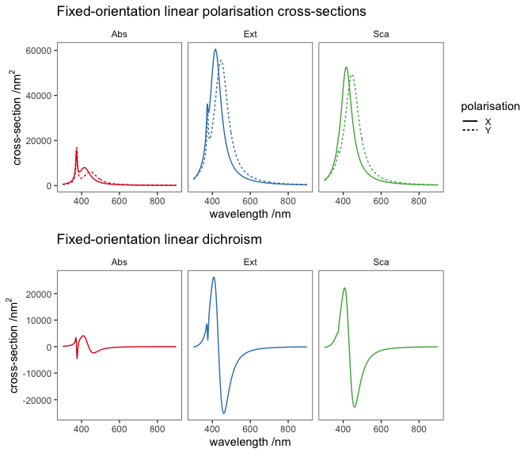

The following files contain fixed-orientation cross-sections for L and R circular polarisations,

```
[1] "csAbs3R.dat" "csAbs4L.dat" "csExt3R.dat" "csExt4L.dat" "csSca3R.dat"
[6] "csSca4L.dat"
```

```
Rows: 8,127
Columns: 7
$ wavelength    <dbl> 300, 302, 304, 306, 308, 310, 312, 314, 316, 318, 320, 3…
$ crosstype     <chr> "Abs", "Abs", "Abs", "Abs", "Abs", "Abs", "Abs", "Abs", …
$ variable      <fct> total, total, total, total, total, total, total, total, …
$ polarisation1 <dbl> 540.1854, 560.5598, 582.0093, 604.6157, 628.4701, 653.67…
$ polarisation2 <dbl> 540.1854, 560.5598, 582.0093, 604.6157, 628.4701, 653.67…
$ dichroism     <dbl> -1.080025e-11, -8.412826e-12, -1.352873e-11, -1.250555e-…
$ average       <dbl> 540.1854, 560.5598, 582.0093, 604.6157, 628.4701, 653.67…
```

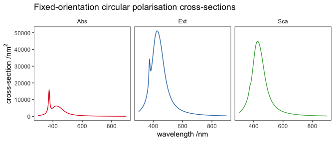

Note that for this configuration there is no circular dichroism, even with fixed incidence.

*Last run: 11 October, 2021*